# Biostat 212a Homework 5

Due Mar 11, 2024 @ 11:59PM

Author

Yang An and UID:106332601

Published

March 12, 2024

## 1 ISL Exercise 9.7.1 (10pts)

1. This problem involves hyperplanes in two dimensions.
1. Sketch the hyperplane 1 + 3X1 − X2 = 0. Indicate the set of points for which 1+3X1 −X2 > 0, as well as the set of points for which 1 + 3X1 − X2 < 0.
2. On the same plot, sketch the hyperplane −2 + X1 + 2X2 = 0. Indicate the set of points for which −2 + X1 + 2X2 > 0, as well as the set of points for which−2+X1+2X2 <0. **Answer** （a) Plotting the line: 1+3X1−X2=0⟺X2=3X1+1 Rearranging for X2 makes it clear which side of the hyperplane is which: 1+3X1−X2<0⟺X2>1+3X1 1+3X1−X2>0⟺X2<1+3X1

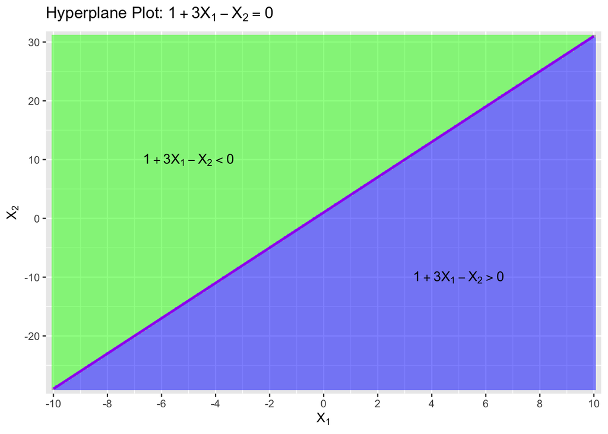

```r
library(ggplot2)
library(dplyr)
library(latex2exp)

X1 <- -10:10
X2 <- 3*X1 + 1

df1 <- data.frame(X1, X2, line = "a")

grid <- expand.grid(X1 = seq(min(df1$X1), max(df1$X1), length.out = 150),
                    X2 = seq(min(df1$X2), max(df1$X2), length.out = 150)) %>%
  mutate(region = case_when(1 + 3*X1 - X2 < 0 ~ "lt 0",
                            1 + 3*X1 - X2 > 0 ~ "gt 0"))

ggplot(grid, aes(x = X1, y = X2)) +
  geom_tile(aes(fill = region), alpha = 0.5) +
  geom_line(data = df1, aes(x = X1, y = X2), size = 1, col = "purple") +
  annotate("text", x = -5, y = 10,
           label = TeX("$1 + 3X_1 - X_2 < 0$", output = "character"),
           hjust = 0.5, size = 4, parse = TRUE, col = "black") +
  annotate("text", x = 5, y = -10,
           label = TeX("$1 + 3X_1 - X_2 > 0$", output = "character"),
           hjust = 0.5, size = 4, parse = TRUE, col = "black") +
  scale_fill_manual(values = c("blue", "green")) +
  scale_x_continuous(expand = c(0.01,0.01), breaks = seq(-10, 10, 2)) +
  scale_y_continuous(expand = c(0.01,0.01), breaks = seq(-30, 30, 10)) +
  theme(legend.position = "none") +
  labs(title = TeX(r'(Hyperplane Plot: $1 + 3X_1 - X_2 = 0$)'),
       x = TeX(r'($X_1$)'),
       y = TeX(r'($X_2$)'))
```

（b) Plotting the line: −2+X1+2X2=0⟺X2=−X1/2+1 Rearranging for X2 makes it clear which side of the hyperplane is which: −2+X1+2X2<0⟺X2<−X1/2+1 −2+X1+2X2>0⟺X2>−X1/2+1

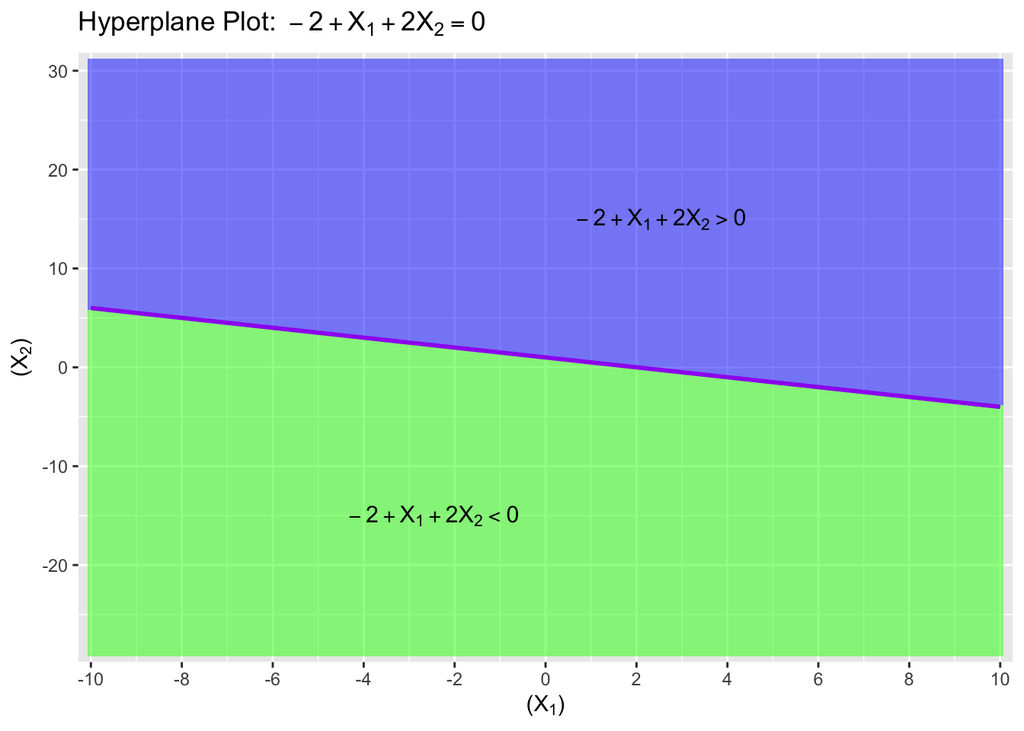

```r
library(ggplot2)
library(dplyr)
library(latex2exp)
X1 <- -10:10
X2 <- 1 - 0.5*X1

df2 <- data.frame(X1, X2, line = "b")

grid <- grid %>%
  mutate(region = case_when(-2 + X1 + 2*X2 < 0 ~ "lt 0",
                            -2 + X1 + 2*X2 > 0 ~ "gt 0"))

ggplot(grid, aes(x = X1, y = X2)) +
  geom_tile(aes(fill = region), alpha = 0.5) +
  geom_line(data = df2, aes(x = X1, y = X2), size = 1, col = "purple") +
  annotate("text", x = 2.5, y = 15,
           label = TeX("$-2 + X_1 + 2X_2 > 0$", output = "character"),
           hjust = 0.5, size = 4, parse = TRUE, col = "black") +
  annotate("text", x = -2.5, y = -15,
           label = TeX("$-2 + X_1 + 2X_2 < 0$", output = "character"),
           hjust = 0.5, size = 4, parse = TRUE, col = "black") +
  scale_fill_manual(values = c("blue", "green")) +
  scale_x_continuous(expand = c(0.01,0.01), breaks = seq(-10, 10, 2)) +
  scale_y_continuous(expand = c(0.01,0.01), breaks = seq(-30, 30, 10)) +
  theme(legend.position = "none") +
  labs(title = TeX("Hyperplane Plot: $-2 + X_1 + 2X_2 = 0$"),
       x = TeX("($X_1$)"),
       y = TeX("($X_2$)"))
```

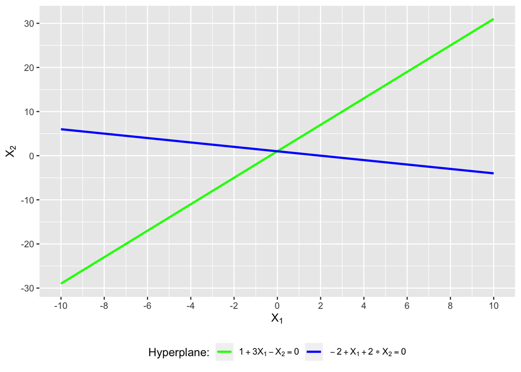

```r
library(ggplot2)
library(dplyr)
library(latex2exp)
bind_rows(df1, df2) %>%
  ggplot(aes(x = X1, y = X2, col = line)) +
  geom_line(size = 1) +
  scale_color_manual(values = c("green", "blue"),
                     labels = unname(TeX(c("$1 + 3X_1 - X_2 = 0", "$-2 + X_1 + 2*X_2 = 0$")))) +
  scale_x_continuous(breaks = seq(-10, 10, 2)) +
  scale_y_continuous(breaks = seq(-30, 30, 10)) +
  labs(x = TeX(r'($X_1$)'),
       y = TeX(r'($X_2$)'),
       col = "Hyperplane:") +
  theme(legend.position = "bottom")
```

## 2 ISL Exercise 9.7.2 (10pts)

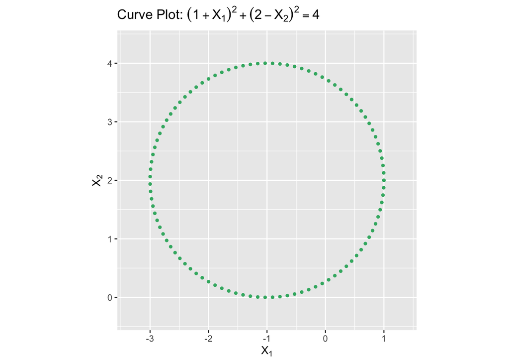

```r
library(ggplot2)

# Define the circle's data
create_circle <- function(x_center, y_center, radius, n_points = 100) {
  t <- seq(0, 2 * pi, length.out = n_points)
  x <- x_center + radius * cos(t)
  y <- y_center + radius * sin(t)
  data.frame(x, y)
}
circle_data <- data.frame(X1 = -1, X2 = 2, r = 2)

# Create ggplot object
ggplot() +
   geom_point(data = create_circle(-1, 2, 2), aes(x, y),
             color = "mediumseagreen", size = 1) +
  scale_x_continuous(expand = c(0.01, 0.01), limits = c(-3.5, 1.5)) +
  scale_y_continuous(expand = c(0.01, 0.01), limits = c(-0.5, 4.5)) +
  labs(
    title = TeX(r'(Curve Plot: $(1 + X_1)^2 + (2 - X_2)^2 = 4$)'),
    x = TeX(r'($X_1$)'),
    y = TeX(r'($X_2$)')
  ) +
  coord_fixed()
```

2. The set of points for which (1+X1)2 +(2−X2)2 >4 is the set of points outside the circle, and the set of points for which (1+X1)2 +(2−X2)2 ≤4 is the set of points inside the circle.

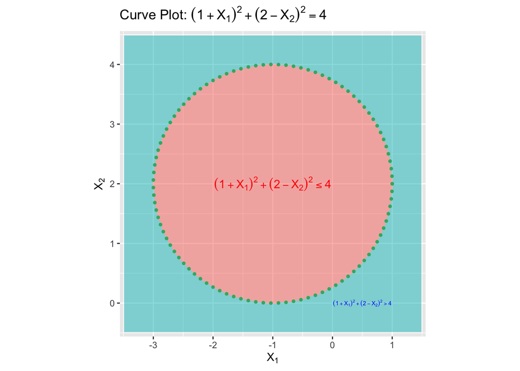

```r
library(ggplot2)
library(dplyr)

# Define custom function to create a circle
create_circle <- function(x_center, y_center, radius, n_points = 100) {
  t <- seq(0, 2 * pi, length.out = n_points)
  x <- x_center + radius * cos(t)
  y <- y_center + radius * sin(t)
  data.frame(x, y)
}

# Generate grid data
grid <- expand.grid(X1 = seq(-3.5, 1.5, length.out = 200),
                    X2 = seq(-0.5, 4.5, length.out = 200)) %>%
  mutate(region = ifelse((1 + X1)^2 + (2 - X2)^2 > 4, "gt 4", "le 4"))

# Create ggplot object
ggplot() +
  geom_tile(data = grid, aes(x = X1, y = X2, fill = region), alpha = 0.5) +
  geom_point(data = create_circle(-1, 2, 2), aes(x, y),
             color = "mediumseagreen", size = 1) +
  annotate("text", x = -1, y = 2,
           label = TeX("$(1 + X_1)^2 + (2 - X_2)^2 \\leq 4$"),
           hjust = 0.5, size = 4, parse = TRUE, col = "red") +
  annotate("text", x = 0.5, y = 0,
           label = TeX("$(1 + X_1)^2 + (2 - X_2)^2 > 4$"),
           hjust = 0.5 , size = 2, parse = TRUE, col = "blue") +
  scale_x_continuous(expand = c(0.01,0.01), limits = c(-3.5, 1.5)) +
  scale_y_continuous(expand = c(0.01,0.01), limits = c(-0.5, 4.5)) +
  scale_fill_manual(values = c("#00BFC4", "#F8766D")) +
  theme(legend.position = "none") +
  labs(title = TeX(r'(Curve Plot: $(1 + X_1)^2 + (2 - X_2)^2 = 4$)'),
       x = TeX(r'($X_1$)'),
       y = TeX(r'($X_2$)')) +
  coord_fixed()
```

3. The observation (1+X1)2 +(2−X2)2 >4, (0, 0) is classified as blue, (−1, 1) is classified as red, (2, 2) is classified as blue, and (3, 8) is classified as blue.

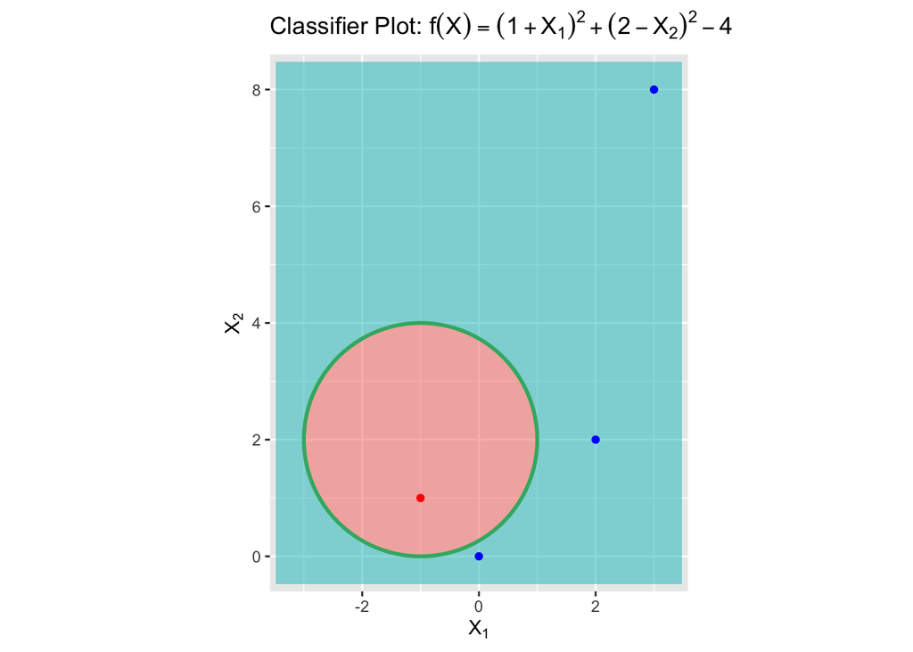

```r
library(ggplot2)
library(dplyr)

# Define custom function to create a circle
create_circle <- function(x_center, y_center, radius, n_points = 100) {
  t <- seq(0, 2 * pi, length.out = n_points)
  x <- x_center + radius * cos(t)
  y <- y_center + radius * sin(t)
  data.frame(x, y)
}

# Define data for new observations
new_obs <- data.frame(X1 = c(0, -1, 2, 3), X2 = c(0, 1, 2, 8)) %>%
  mutate(region = ifelse((1 + X1)^2 + (2 - X2)^2 > 4, "gt 4", "le 4"))

# Generate grid data
grid <- expand.grid(X1 = seq(-3.5, 3.5, length.out = 200),
                    X2 = seq(-0.5, 8.5, length.out = 200)) %>%
  mutate(region = ifelse((1 + X1)^2 + (2 - X2)^2 > 4, "gt 4", "le 4"))

# Create ggplot object
ggplot() +
  geom_tile(data = grid, aes(x = X1, y = X2, fill = region), alpha = 0.5) +
  geom_path(data = create_circle(-1, 2, 2), aes(x, y),
            col = "mediumseagreen", size = 1) +
  geom_point(data = new_obs, aes(x = X1, y = X2, col = region)) +
  scale_x_continuous(expand = c(0.01,0.01), limits = c(-3.5, 3.5)) +
  scale_y_continuous(expand = c(0.01,0.01), limits = c(-0.5, 8.5)) +
  scale_fill_manual(values = c("#00BFC4", "#F8766D")) +
  scale_color_manual(values = c("blue", "red")) +
  theme(legend.position = "none") +
  labs(title = TeX(r'(Classifier Plot: $f(X) = (1 + X_1)^2 + (2 - X_2)^2 - 4$)'
                   ),
       x = TeX(r'($X_1$)'),
       y = TeX(r'($X_2$)')) +
  coord_fixed()
```

The decision boundary is defined as the boundary where the function f(X) changes its sign. In this case, f(X)=0 represents the boundary because it’s where the prediction changes.
$$\begin{align*}
f(X) & \Rightarrow f(X) = 0 \\
& = (1 + X_1)^2 + (2 - X_2)^2 - 4 \\
& = X_1^2 + 2X_1 + 1 + X_2^2 - 4X_2 + 4 - 4 \\
& = X_1^2 + X_2^2 + 2X_1 - 4X_2 + 1 \\
& = (1)(X_1^2) + (1)(X_2^2) + (2)(X_1) + (-4)(X_2) + 1 = 0
\end{align*}$$
From the final form we can see how f(X)=0 is expressed in the form a1Z1+a2Z2+ a3Z3+a4Z4+b=0 for (Z1,Z2,Z3,Z4)=(X21,X22,X1,X2), and therefore it is linear in terms of x1, x1^2, x2, and x2^2. Thus, the decision boundary is a circle in the feature space.

## 3 Support vector machines (SVMs) on the `Carseats` data set (30pts)

Follow the machine learning workflow to train support vector classifier (same as SVM with linear kernel), SVM with polynomial kernel (tune the degree and regularization parameter $C$), and SVM with radial kernel (tune the scale parameter $\gamma$ and regularization parameter $C$) for classifying `Sales<=8` versus `Sales>8`. Use the same seed as in your HW4 for the initial test/train split and compare the final test AUC and accuracy to those methods you tried in HW4.

### 3.1 Machine Learning Workflow: SVM with Polynomial Kernel (Carseats Data)

```r
# Load necessary libraries
library(GGally)
library(gtsummary)
library(ranger)
library(tidyverse)
library(tidymodels)
library(ISLR2)

# Load the dataset
Sales <- ISLR2::Carseats %>%
  mutate(Sales = ifelse(Sales <= 8, "Low", "High"))
  # Check the structure of the dataset
glimpse(Sales)
```

```
Rows: 400
Columns: 11
$ Sales       <chr> "High", "High", "High", "Low", "Low", "High", "Low", "High…
$ CompPrice   <dbl> 138, 111, 113, 117, 141, 124, 115, 136, 132, 132, 121, 117…
$ Income      <dbl> 73, 48, 35, 100, 64, 113, 105, 81, 110, 113, 78, 94, 35, 2…
$ Advertising <dbl> 11, 16, 10, 4, 3, 13, 0, 15, 0, 0, 9, 4, 2, 11, 11, 5, 0, …
$ Population  <dbl> 276, 260, 269, 466, 340, 501, 45, 425, 108, 131, 150, 503,…
$ Price       <dbl> 120, 83, 80, 97, 128, 72, 108, 120, 124, 124, 100, 94, 136…
$ ShelveLoc   <fct> Bad, Good, Medium, Medium, Bad, Bad, Medium, Good, Medium,…
$ Age         <dbl> 42, 65, 59, 55, 38, 78, 71, 67, 76, 76, 26, 50, 62, 53, 52…
$ Education   <dbl> 17, 10, 12, 14, 13, 16, 15, 10, 10, 17, 10, 13, 18, 18, 18…
$ Urban       <fct> Yes, Yes, Yes, Yes, Yes, No, Yes, Yes, No, No, No, Yes, Ye…
$ US          <fct> Yes, Yes, Yes, Yes, No, Yes, No, Yes, No, Yes, Yes, Yes, N…
```

```r
# Numerical summaries stratified by the outcome `Sales`.
Sales %>% tbl_summary(by = Sales)
```

| **Characteristic** | **High**, N = 164<sup>1</sup> | **Low**, N = 236<sup>1</sup> |
| --- | --- | --- |
| CompPrice | 127 (115, 136) | 124 (115, 134) |
| Income | 76 (58, 94) | 65 (40, 88) |
| Advertising | 10.0 (0.0, 14.0) | 3.0 (0.0, 10.0) |
| Population | 276 (150, 403) | 268 (132, 389) |
| Price | 107 (90, 123) | 122 (107, 135) |
| ShelveLoc |  |  |
| Bad | 14 (8.5%) | 82 (35%) |
| Good | 66 (40%) | 19 (8.1%) |
| Medium | 84 (51%) | 135 (57%) |
| Age | 49 (36, 61) | 58 (42, 70) |
| Education |  |  |
| 10 | 25 (15%) | 23 (9.7%) |
| 11 | 17 (10%) | 31 (13%) |
| 12 | 19 (12%) | 30 (13%) |
| 13 | 17 (10%) | 26 (11%) |
| 14 | 14 (8.5%) | 26 (11%) |
| 15 | 18 (11%) | 18 (7.6%) |
| 16 | 18 (11%) | 29 (12%) |
| 17 | 21 (13%) | 28 (12%) |
| 18 | 15 (9.1%) | 25 (11%) |
| Urban | 110 (67%) | 172 (73%) |
| US | 123 (75%) | 135 (57%) |

<sup>1</sup> Median (IQR); n (%)

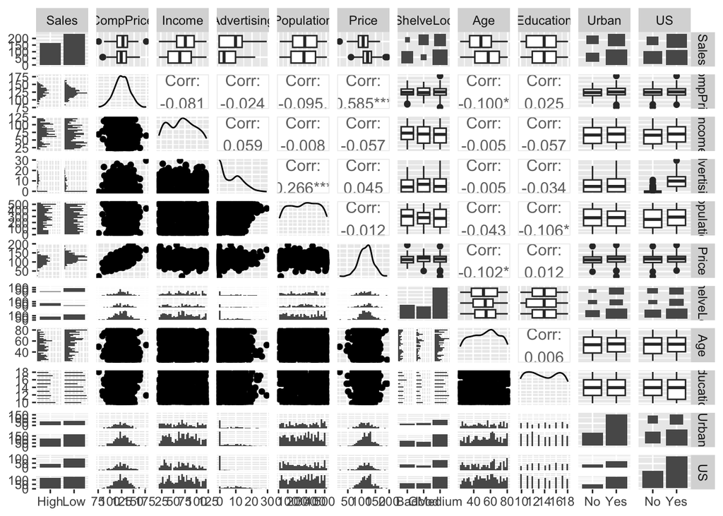

```r
# Graphical summary:
 Sales %>% ggpairs()
```

```r
# For reproducibility
set.seed(203)

data_split <- initial_split(
  Sales,
  # stratify by AHD
  strata = "Sales",
  prop = 0.75
  )
data_split
```

```
<Training/Testing/Total>
<300/100/400>
```

```r
Sales_other <- training(data_split)
dim(Sales_other)
```

```
[1] 300  11
```

```r
Sales_test <- testing(data_split)
dim(Sales_test)
```

```
[1] 100  11
```

```r
svm_recipe <-
  recipe(
    Sales ~ .,
    data = Sales_other
  ) %>%
  # create traditional dummy variables (necessary for svm)
  step_dummy(all_nominal_predictors()) %>%
  # zero-variance filter
  step_zv(all_numeric_predictors()) %>%
  # center and scale numeric data
  step_normalize(all_numeric_predictors())
svm_recipe
```

```r
svm_mod <-
  svm_poly(
    mode = "classification",
    cost = tune(),
    degree = tune(),
    # scale_factor = tune()
  ) %>%
  set_engine("kernlab")
svm_mod
```

```
Polynomial Support Vector Machine Model Specification (classification)

Main Arguments:
  cost = tune()
  degree = tune()

Computational engine: kernlab
```

```r
svm_wf <- workflow() %>%
  add_recipe(svm_recipe) %>%
  add_model(svm_mod)
svm_wf
```

```
══ Workflow ════════════════════════════════════════════════════════════════════
Preprocessor: Recipe
Model: svm_poly()

── Preprocessor ────────────────────────────────────────────────────────────────
3 Recipe Steps

• step_dummy()
• step_zv()
• step_normalize()

── Model ───────────────────────────────────────────────────────────────────────
Polynomial Support Vector Machine Model Specification (classification)

Main Arguments:
  cost = tune()
  degree = tune()

Computational engine: kernlab
```

```r
param_grid <- grid_regular(
  cost(range = c(-3, 2)),
  degree(range = c(1, 5)),
  #scale_factor(range = c(-1, 1)),
  levels = c(5)
  )
param_grid
```

```
# A tibble: 25 × 2
    cost degree
   <dbl>  <dbl>
 1 0.125      1
 2 0.297      1
 3 0.707      1
 4 1.68       1
 5 4          1
 6 0.125      2
 7 0.297      2
 8 0.707      2
 9 1.68       2
10 4          2
# ℹ 15 more rows
```

```r
set.seed(203)

folds <- vfold_cv(Sales_other, v = 5)
folds
```

```
#  5-fold cross-validation
# A tibble: 5 × 2
  splits           id
  <list>           <chr>
1 <split [240/60]> Fold1
2 <split [240/60]> Fold2
3 <split [240/60]> Fold3
4 <split [240/60]> Fold4
5 <split [240/60]> Fold5
```

```r
svm_fit <- svm_wf %>%
  tune_grid(
    resamples = folds,
    grid = param_grid,
    metrics = metric_set(roc_auc, accuracy)
    )
svm_fit
```

```
# Tuning results
# 5-fold cross-validation
# A tibble: 5 × 4
  splits           id    .metrics          .notes
  <list>           <chr> <list>            <list>
1 <split [240/60]> Fold1 <tibble [50 × 6]> <tibble [0 × 3]>
2 <split [240/60]> Fold2 <tibble [50 × 6]> <tibble [0 × 3]>
3 <split [240/60]> Fold3 <tibble [50 × 6]> <tibble [0 × 3]>
4 <split [240/60]> Fold4 <tibble [50 × 6]> <tibble [0 × 3]>
5 <split [240/60]> Fold5 <tibble [50 × 6]> <tibble [0 × 3]>
```

```
# A tibble: 50 × 8
    cost degree .metric  .estimator  mean     n std_err .config
   <dbl>  <dbl> <chr>    <chr>      <dbl> <int>   <dbl> <chr>
 1 0.125      1 accuracy binary     0.873     5 0.0172  Preprocessor1_Model01
 2 0.125      1 roc_auc  binary     0.952     5 0.00836 Preprocessor1_Model01
 3 0.297      1 accuracy binary     0.853     5 0.0122  Preprocessor1_Model02
 4 0.297      1 roc_auc  binary     0.948     5 0.00754 Preprocessor1_Model02
 5 0.707      1 accuracy binary     0.857     5 0.0113  Preprocessor1_Model03
 6 0.707      1 roc_auc  binary     0.943     5 0.00678 Preprocessor1_Model03
 7 1.68       1 accuracy binary     0.86      5 0.0125  Preprocessor1_Model04
 8 1.68       1 roc_auc  binary     0.947     5 0.00891 Preprocessor1_Model04
 9 4          1 accuracy binary     0.863     5 0.00972 Preprocessor1_Model05
10 4          1 roc_auc  binary     0.947     5 0.00571 Preprocessor1_Model05
# ℹ 40 more rows
```

[figure not shown]

```r
svm_fit %>%
  collect_metrics() %>%
  print(width = Inf) %>%
  filter(.metric == "roc_auc" ) %>%
  ggplot(mapping = aes(x = degree, y = mean)) +
  geom_point() +
  geom_line() +
  labs(x = "Cost", y = "CV AUC") +
  scale_x_log10()
```

```r
svm_fit %>%
  show_best("roc_auc")
```

```
# A tibble: 5 × 8
   cost degree .metric .estimator  mean     n std_err .config
  <dbl>  <dbl> <chr>   <chr>      <dbl> <int>   <dbl> <chr>
1 0.125      1 roc_auc binary     0.952     5 0.00836 Preprocessor1_Model01
2 0.297      1 roc_auc binary     0.948     5 0.00754 Preprocessor1_Model02
3 1.68       1 roc_auc binary     0.947     5 0.00891 Preprocessor1_Model04
4 4          1 roc_auc binary     0.947     5 0.00571 Preprocessor1_Model05
5 0.707      1 roc_auc binary     0.943     5 0.00678 Preprocessor1_Model03
```

```r
best_svm <- svm_fit %>%
  select_best("roc_auc")
best_svm
```

```
# A tibble: 1 × 3
   cost degree .config
  <dbl>  <dbl> <chr>
1 0.125      1 Preprocessor1_Model01
```

```r
# Final workflow
final_wf <- svm_wf %>%
  finalize_workflow(best_svm)
final_wf
```

```
══ Workflow ════════════════════════════════════════════════════════════════════
Preprocessor: Recipe
Model: svm_poly()

── Preprocessor ────────────────────────────────────────────────────────────────
3 Recipe Steps

• step_dummy()
• step_zv()
• step_normalize()

── Model ───────────────────────────────────────────────────────────────────────
Polynomial Support Vector Machine Model Specification (classification)

Main Arguments:
  cost = 0.125
  degree = 1

Computational engine: kernlab
```

```r
# Fit the whole training set, then predict the test cases
final_fit <-
  final_wf %>%
  last_fit(data_split)
final_fit
```

```
# Resampling results
# Manual resampling
# A tibble: 1 × 6
  splits            id               .metrics .notes   .predictions .workflow
  <list>            <chr>            <list>   <list>   <list>       <list>
1 <split [300/100]> train/test split <tibble> <tibble> <tibble>     <workflow>
```

```r
# Test metrics
final_fit %>%
  collect_metrics()
```

```
# A tibble: 2 × 4
  .metric  .estimator .estimate .config
  <chr>    <chr>          <dbl> <chr>
1 accuracy binary         0.87  Preprocessor1_Model1
2 roc_auc  binary         0.957 Preprocessor1_Model1
```

```r
install.packages("doParallel", repos = "https://cloud.r-project.org/")
library(doParallel)

set.seed(101)
split_obj <- initial_split(data = Sales, prop = 0.7, strata = Sales)
train <- training(split_obj)
test <- testing(split_obj)


# Create the recipe
recipe(Sales ~ ., data = train) %>%
  # create traditional dummy variables (necessary for svm)
  step_dummy(all_nominal_predictors()) %>%
  # zero-variance filter
  step_zv(all_numeric_predictors()) %>%
  # center and scale numeric data
  step_normalize(all_numeric_predictors()) %>%
  # estimate the means and standard deviations
  prep() -> recipe_obj

# Bake
train <- bake(recipe_obj, new_data=train)
test <- bake(recipe_obj, new_data=test)
```

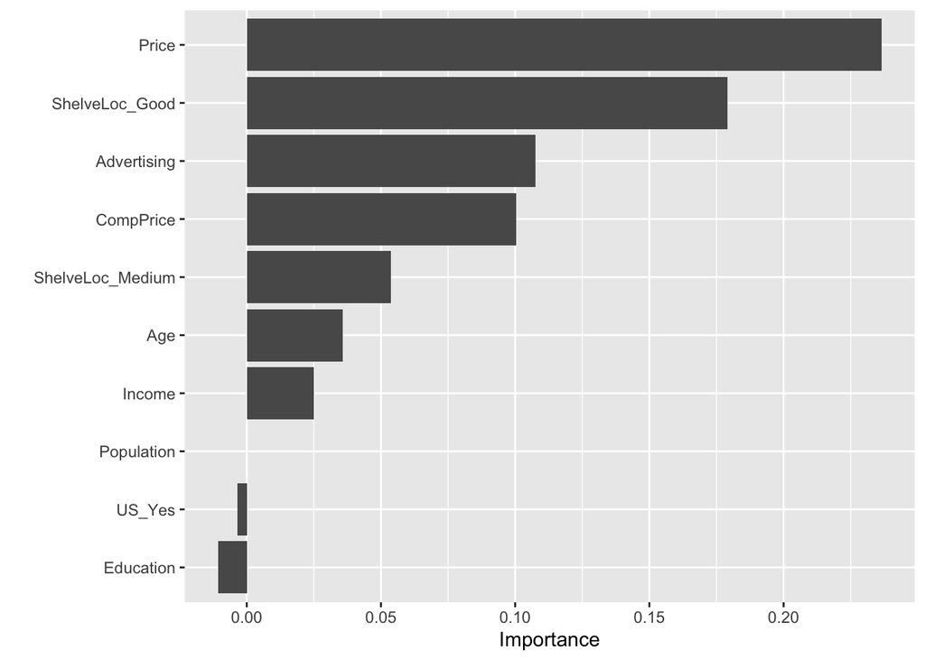

```r
library(vip)
final_fit %>%
  pluck(".workflow", 1) %>%
  pull_workflow_fit() %>%
  # vip(method = "permute", train= Sales)
  vip(method = "permute",
      target = "Sales", metric = "accuracy",
      pred_wrapper = kernlab::predict, train = train)
```

```r
# Check for missing values in the training data
any_missing <- any(is.na(train))
any_missing
```

```
[1] FALSE
```

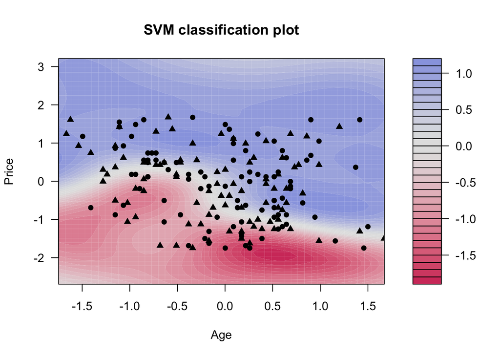

```r
svm_rbf_spec <- svm_rbf() %>%
  set_mode("classification") %>%
  set_engine("kernlab")

svm_rbf_fit <- svm_rbf_spec %>%
  fit(Sales ~ ., data = train[, c('Price', 'Age', 'Sales')])

svm_rbf_fit %>%
  extract_fit_engine() %>%
  plot()
```

### 3.2 Machine Learning Workflow: SVM with RBF Kernel (Carseats Data))

```r
# Load libraries
library(GGally)
library(gtsummary)
library(kernlab)
library(tidyverse)
library(tidymodels)
library(ISLR2)

# Load the dataset
Carsets <- ISLR2::Carseats %>%
  mutate(Sales = ifelse(Sales <= 8, "Low", "High"))
  # Check the structure of the dataset
glimpse(Carsets)
```

```
Rows: 400
Columns: 11
$ Sales       <chr> "High", "High", "High", "Low", "Low", "High", "Low", "High…
$ CompPrice   <dbl> 138, 111, 113, 117, 141, 124, 115, 136, 132, 132, 121, 117…
$ Income      <dbl> 73, 48, 35, 100, 64, 113, 105, 81, 110, 113, 78, 94, 35, 2…
$ Advertising <dbl> 11, 16, 10, 4, 3, 13, 0, 15, 0, 0, 9, 4, 2, 11, 11, 5, 0, …
$ Population  <dbl> 276, 260, 269, 466, 340, 501, 45, 425, 108, 131, 150, 503,…
$ Price       <dbl> 120, 83, 80, 97, 128, 72, 108, 120, 124, 124, 100, 94, 136…
$ ShelveLoc   <fct> Bad, Good, Medium, Medium, Bad, Bad, Medium, Good, Medium,…
$ Age         <dbl> 42, 65, 59, 55, 38, 78, 71, 67, 76, 76, 26, 50, 62, 53, 52…
$ Education   <dbl> 17, 10, 12, 14, 13, 16, 15, 10, 10, 17, 10, 13, 18, 18, 18…
$ Urban       <fct> Yes, Yes, Yes, Yes, Yes, No, Yes, Yes, No, No, No, Yes, Ye…
$ US          <fct> Yes, Yes, Yes, Yes, No, Yes, No, Yes, No, Yes, Yes, Yes, N…
```

```r
# Numerical summaries stratified by the outcome `Sales`.
Carsets %>% tbl_summary(by = Sales)
```

| **Characteristic** | **High**, N = 164<sup>1</sup> | **Low**, N = 236<sup>1</sup> |
| --- | --- | --- |
| CompPrice | 127 (115, 136) | 124 (115, 134) |
| Income | 76 (58, 94) | 65 (40, 88) |
| Advertising | 10.0 (0.0, 14.0) | 3.0 (0.0, 10.0) |
| Population | 276 (150, 403) | 268 (132, 389) |
| Price | 107 (90, 123) | 122 (107, 135) |
| ShelveLoc |  |  |
| Bad | 14 (8.5%) | 82 (35%) |
| Good | 66 (40%) | 19 (8.1%) |
| Medium | 84 (51%) | 135 (57%) |
| Age | 49 (36, 61) | 58 (42, 70) |
| Education |  |  |
| 10 | 25 (15%) | 23 (9.7%) |
| 11 | 17 (10%) | 31 (13%) |
| 12 | 19 (12%) | 30 (13%) |
| 13 | 17 (10%) | 26 (11%) |
| 14 | 14 (8.5%) | 26 (11%) |
| 15 | 18 (11%) | 18 (7.6%) |
| 16 | 18 (11%) | 29 (12%) |
| 17 | 21 (13%) | 28 (12%) |
| 18 | 15 (9.1%) | 25 (11%) |
| Urban | 110 (67%) | 172 (73%) |
| US | 123 (75%) | 135 (57%) |

<sup>1</sup> Median (IQR); n (%)

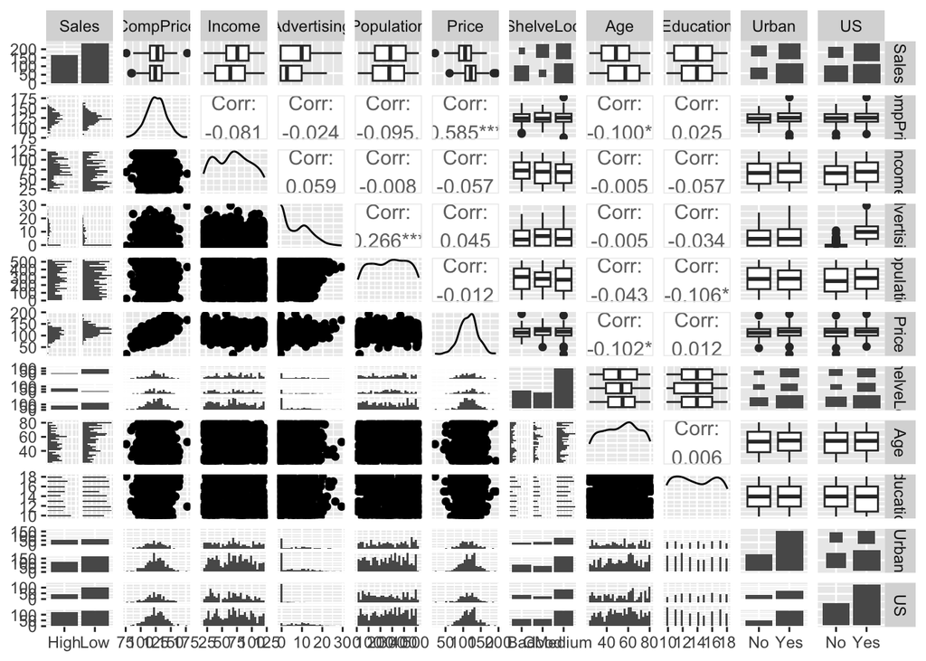

```r
# Graphical summary:
Carsets %>% ggpairs()
```

```r
# For reproducibility
set.seed(203)

data_split2 <- initial_split(
  Carsets,
  # stratify by Sales
  strata = "Sales",
  prop = 0.75
  )
data_split2
```

```
<Training/Testing/Total>
<300/100/400>
```

```r
Carsets_other <- training(data_split2)
dim(Carsets_other)
```

```
[1] 300  11
```

```r
Carsets_test <- testing(data_split2)
dim(Carsets_test)
```

```
[1] 100  11
```

```r
svm_recipe2 <-
  recipe(
    Sales ~ .,
    data = Carsets_other
  ) %>%
  # create traditional dummy variables (necessary for svm)
  step_dummy(all_nominal_predictors()) %>%
  # zero-variance filter
  step_zv(all_numeric_predictors()) %>%
  # center and scale numeric data
  step_normalize(all_numeric_predictors())
svm_recipe2
```

```r
svm_mod2 <-
  svm_rbf(
    mode = "classification",
    cost = tune(),
    rbf_sigma = tune()
  ) %>%
  set_engine("kernlab")
svm_mod2
```

```
Radial Basis Function Support Vector Machine Model Specification (classification)

Main Arguments:
  cost = tune()
  rbf_sigma = tune()

Computational engine: kernlab
```

```r
svm_wf2 <- workflow() %>%
  add_recipe(svm_recipe2) %>%
  add_model(svm_mod2)
svm_wf2
```

```
══ Workflow ════════════════════════════════════════════════════════════════════
Preprocessor: Recipe
Model: svm_rbf()

── Preprocessor ────────────────────────────────────────────────────────────────
3 Recipe Steps

• step_dummy()
• step_zv()
• step_normalize()

── Model ───────────────────────────────────────────────────────────────────────
Radial Basis Function Support Vector Machine Model Specification (classification)

Main Arguments:
  cost = tune()
  rbf_sigma = tune()

Computational engine: kernlab
```

```r
param_grid2 <- grid_regular(
  cost(range = c(-8, 5)),
  rbf_sigma(range = c(-5, -3)),
  levels = c(14, 5)
  )
param_grid2
```

```
# A tibble: 70 × 2
      cost rbf_sigma
     <dbl>     <dbl>
 1 0.00391   0.00001
 2 0.00781   0.00001
 3 0.0156    0.00001
 4 0.0312    0.00001
 5 0.0625    0.00001
 6 0.125     0.00001
 7 0.25      0.00001
 8 0.5       0.00001
 9 1         0.00001
10 2         0.00001
# ℹ 60 more rows
```

```r
set.seed(203)

folds2 <- vfold_cv(Carsets_other, v = 5)
folds2
```

```
#  5-fold cross-validation
# A tibble: 5 × 2
  splits           id
  <list>           <chr>
1 <split [240/60]> Fold1
2 <split [240/60]> Fold2
3 <split [240/60]> Fold3
4 <split [240/60]> Fold4
5 <split [240/60]> Fold5
```

```r
svm_fit2 <- svm_wf2 %>%
  tune_grid(
    resamples = folds2,
    grid = param_grid2,
    metrics = metric_set(roc_auc, accuracy)
    )
svm_fit2
```

```
# Tuning results
# 5-fold cross-validation
# A tibble: 5 × 4
  splits           id    .metrics           .notes
  <list>           <chr> <list>             <list>
1 <split [240/60]> Fold1 <tibble [140 × 6]> <tibble [0 × 3]>
2 <split [240/60]> Fold2 <tibble [140 × 6]> <tibble [0 × 3]>
3 <split [240/60]> Fold3 <tibble [140 × 6]> <tibble [0 × 3]>
4 <split [240/60]> Fold4 <tibble [140 × 6]> <tibble [0 × 3]>
5 <split [240/60]> Fold5 <tibble [140 × 6]> <tibble [0 × 3]>
```

```
# A tibble: 140 × 8
      cost rbf_sigma .metric  .estimator  mean     n std_err
     <dbl>     <dbl> <chr>    <chr>      <dbl> <int>   <dbl>
 1 0.00391   0.00001 accuracy binary     0.59      5  0.0233
 2 0.00391   0.00001 roc_auc  binary     0.879     5  0.0158
 3 0.00781   0.00001 accuracy binary     0.59      5  0.0233
 4 0.00781   0.00001 roc_auc  binary     0.879     5  0.0158
 5 0.0156    0.00001 accuracy binary     0.59      5  0.0233
 6 0.0156    0.00001 roc_auc  binary     0.879     5  0.0158
 7 0.0312    0.00001 accuracy binary     0.59      5  0.0233
 8 0.0312    0.00001 roc_auc  binary     0.879     5  0.0158
 9 0.0625    0.00001 accuracy binary     0.59      5  0.0233
10 0.0625    0.00001 roc_auc  binary     0.879     5  0.0158
   .config
   <chr>
 1 Preprocessor1_Model01
 2 Preprocessor1_Model01
 3 Preprocessor1_Model02
 4 Preprocessor1_Model02
 5 Preprocessor1_Model03
 6 Preprocessor1_Model03
 7 Preprocessor1_Model04
 8 Preprocessor1_Model04
 9 Preprocessor1_Model05
10 Preprocessor1_Model05
# ℹ 130 more rows
```

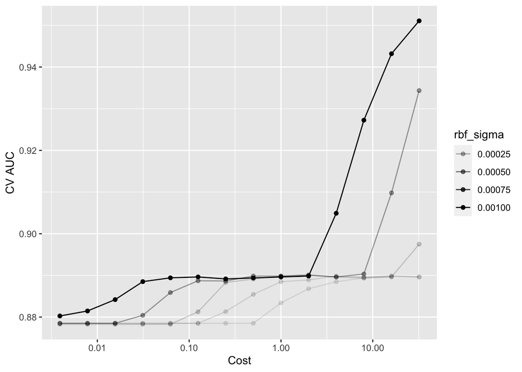

```r
svm_fit2 %>%
  collect_metrics() %>%
  print(width = Inf) %>%
  filter(.metric == "roc_auc") %>%
  ggplot(mapping = aes(x = cost, y = mean, alpha = rbf_sigma)) +
  geom_point() +
  geom_line(aes(group = rbf_sigma)) +
  labs(x = "Cost", y = "CV AUC") +
  scale_x_log10()
```

```r
svm_fit2 %>%
  show_best("roc_auc")
```

```
# A tibble: 5 × 8
   cost rbf_sigma .metric .estimator  mean     n std_err .config
  <dbl>     <dbl> <chr>   <chr>      <dbl> <int>   <dbl> <chr>
1    32  0.001    roc_auc binary     0.951     5 0.00997 Preprocessor1_Model70
2    16  0.001    roc_auc binary     0.943     5 0.0113  Preprocessor1_Model69
3    32  0.000316 roc_auc binary     0.934     5 0.0122  Preprocessor1_Model56
4     8  0.001    roc_auc binary     0.927     5 0.0121  Preprocessor1_Model68
5    16  0.000316 roc_auc binary     0.910     5 0.0136  Preprocessor1_Model55
```

```r
best_svm2 <- svm_fit2 %>%
  select_best("roc_auc")
best_svm2
```

```
# A tibble: 1 × 3
   cost rbf_sigma .config
  <dbl>     <dbl> <chr>
1    32     0.001 Preprocessor1_Model70
```

```r
# Final workflow
final_wf2 <- svm_wf2 %>%
  finalize_workflow(best_svm2)
final_wf2
```

```
══ Workflow ════════════════════════════════════════════════════════════════════
Preprocessor: Recipe
Model: svm_rbf()

── Preprocessor ────────────────────────────────────────────────────────────────
3 Recipe Steps

• step_dummy()
• step_zv()
• step_normalize()

── Model ───────────────────────────────────────────────────────────────────────
Radial Basis Function Support Vector Machine Model Specification (classification)

Main Arguments:
  cost = 32
  rbf_sigma = 0.001

Computational engine: kernlab
```

```r
# Fit the whole training set, then predict the test cases
final_fit2 <-
  final_wf2 %>%
  last_fit(data_split2)
final_fit2
```

```
# Resampling results
# Manual resampling
# A tibble: 1 × 6
  splits            id               .metrics .notes   .predictions .workflow
  <list>            <chr>            <list>   <list>   <list>       <list>
1 <split [300/100]> train/test split <tibble> <tibble> <tibble>     <workflow>
```

```r
# Test metrics
final_fit2 %>%
  collect_metrics()
```

```
# A tibble: 2 × 4
  .metric  .estimator .estimate .config
  <chr>    <chr>          <dbl> <chr>
1 accuracy binary         0.84  Preprocessor1_Model1
2 roc_auc  binary         0.948 Preprocessor1_Model1
```

Comparing these metrics: AUC Comparison: The AUC for the current method (0.9479124) is higher than that of the classification tree (0.85), random forest (0.91), and boosting methods (0.92) used in HW4. This indicates that the current method has better discrimination ability in distinguishing between the positive and negative classes compared to the methods used in HW4. Accuracy Comparison: The accuracy of the current method (0.84) is lower than that of random forest (0.88) and slightly lower than the boosting methods (0.87) used in HW4, but it’s higher than that of the classification tree (0.82) used in HW4. Based on these comparisons, the current method seems to outperform the methods used in HW4 in terms of AUC, but its accuracy is slightly lower than random forest and boosting methods while being higher than the classification tree. However, the choice of the best method depends on various factors such as the specific requirements of the application, interpretability, computational complexity, etc.

## 4 Bonus (10pts)

$$f(x) = \beta_0 + \beta^T x$$

Now, we’ll rewrite this equation to express `\beta^T x` in terms of `f(x)`:

$$\beta^T x = f(x) - \beta_0$$

$$d(x) = \frac{{f(x) - \beta_0}}{{|\beta|}}$$